# Model-Human Alignment: Correlation, Accuracy, and Constraint Analysis

## Summary Statistics

```r
cat("\n=== SUMMARY: INITIAL vs. FINAL VALUES ===\n\n")
```

```
##
## === SUMMARY: INITIAL vs. FINAL VALUES ===
```

```r
get_init_final <- function(data, value_col) {
  data %>%
    group_by(model) %>%
    arrange(tokens) %>%
    summarize(
      initial = first({{ value_col }}),
      final   = last({{ value_col }}),
      change  = final - initial,
      .groups = "drop"
    )
}

cat("NONCE - Correlation:\n")
```

```
## NONCE - Correlation:
```

```r
get_init_final(nonce_correlations, correlation) %>% kable(digits = 3)
```

| model | initial | final | change |
| --- | --- | --- | --- |
| znhoughton/opt-babylm-1.3b-64eps-seed964 | -0.210 | 0.195 | 0.405 |
| znhoughton/opt-babylm-125m-64eps-seed964 | 0.100 | -0.033 | -0.132 |
| znhoughton/opt-babylm-350m-64eps-seed964 | 0.072 | -0.003 | -0.074 |
| znhoughton/opt-c4-1.3b-seed964 | -0.219 | -0.018 | 0.201 |
| znhoughton/opt-c4-125m-seed964 | 0.124 | 0.031 | -0.093 |
| znhoughton/opt-c4-350m-seed964 | 0.056 | -0.131 | -0.186 |

```r
cat("\nNONCE - Accuracy:\n")
```

```
##
## NONCE - Accuracy:
```

```r
get_init_final(nonce_accuracy, accuracy) %>% kable(digits = 3)
```

| model | initial | final | change |
| --- | --- | --- | --- |
| znhoughton/opt-babylm-1.3b-64eps-seed964 | 0.420 | 0.542 | 0.122 |
| znhoughton/opt-babylm-125m-64eps-seed964 | 0.397 | 0.481 | 0.084 |
| znhoughton/opt-babylm-350m-64eps-seed964 | 0.382 | 0.489 | 0.107 |
| znhoughton/opt-c4-1.3b-seed964 | 0.397 | 0.458 | 0.061 |
| znhoughton/opt-c4-125m-seed964 | 0.382 | 0.511 | 0.130 |
| znhoughton/opt-c4-350m-seed964 | 0.382 | 0.427 | 0.046 |

```r
cat("\nATTESTED - Correlation:\n")
```

```
##
## ATTESTED - Correlation:
```

```r
get_init_final(attested_correlations, correlation) %>% kable(digits = 3)
```

| model | initial | final | change |
| --- | --- | --- | --- |
| znhoughton/opt-babylm-1.3b-64eps-seed964 | 0.051 | 0.472 | 0.421 |
| znhoughton/opt-babylm-125m-64eps-seed964 | -0.017 | 0.587 | 0.603 |
| znhoughton/opt-babylm-350m-64eps-seed964 | 0.074 | 0.447 | 0.373 |
| znhoughton/opt-c4-1.3b-seed964 | 0.001 | 0.665 | 0.664 |
| znhoughton/opt-c4-125m-seed964 | -0.004 | 0.677 | 0.681 |
| znhoughton/opt-c4-350m-seed964 | 0.061 | 0.551 | 0.490 |

```r
cat("\nATTESTED - Accuracy:\n")
```

```
##
## ATTESTED - Accuracy:
```

```r
get_init_final(attested_accuracy, accuracy) %>% kable(digits = 3)
```

| model | initial | final | change |
| --- | --- | --- | --- |
| znhoughton/opt-babylm-1.3b-64eps-seed964 | 0.490 | 0.662 | 0.172 |
| znhoughton/opt-babylm-125m-64eps-seed964 | 0.483 | 0.692 | 0.209 |
| znhoughton/opt-babylm-350m-64eps-seed964 | 0.498 | 0.614 | 0.116 |
| znhoughton/opt-c4-1.3b-seed964 | 0.500 | 0.685 | 0.185 |
| znhoughton/opt-c4-125m-seed964 | 0.490 | 0.705 | 0.215 |
| znhoughton/opt-c4-350m-seed964 | 0.498 | 0.680 | 0.182 |

```r
cat("\nNONCE - GenPref Coefficient:\n")
```

```
##
## NONCE - GenPref Coefficient:
```

```r
get_init_final(nonce_genpref, coefficient) %>% kable(digits = 3)
```

| model | initial | final | change |
| --- | --- | --- | --- |
| znhoughton/opt-babylm-1.3b-64eps-seed964 | -0.313 | 4.735 | 5.048 |
| znhoughton/opt-babylm-125m-64eps-seed964 | 0.679 | 3.295 | 2.616 |
| znhoughton/opt-babylm-350m-64eps-seed964 | 0.180 | 2.086 | 1.906 |
| znhoughton/opt-c4-1.3b-seed964 | -0.208 | 0.706 | 0.915 |
| znhoughton/opt-c4-125m-seed964 | 0.564 | -0.428 | -0.993 |
| znhoughton/opt-c4-350m-seed964 | 0.163 | -0.399 | -0.562 |

```r
cat("\nATTESTED - GenPref Coefficient:\n")
```

```
##
## ATTESTED - GenPref Coefficient:
```

```r
get_init_final(attested_genpref, coefficient) %>% kable(digits = 3)
```

| model | initial | final | change |
| --- | --- | --- | --- |
| znhoughton/opt-babylm-1.3b-64eps-seed964 | 0.028 | 6.282 | 6.254 |
| znhoughton/opt-babylm-125m-64eps-seed964 | -0.047 | 6.586 | 6.633 |
| znhoughton/opt-babylm-350m-64eps-seed964 | 0.103 | 2.665 | 2.562 |
| znhoughton/opt-c4-1.3b-seed964 | -0.091 | 7.020 | 7.111 |
| znhoughton/opt-c4-125m-seed964 | -0.030 | 6.535 | 6.564 |
| znhoughton/opt-c4-350m-seed964 | 0.086 | 4.672 | 4.585 |

## Analysis 5: Bayesian Mixed-Effects Models

```r
library(brms)

dir.create("brms_cache", showWarnings = FALSE)

# Weakly informative priors centered at zero
bayes_priors <- c(
  prior(normal(0, 0.5), class = b),
  prior(exponential(1), class = sd),
  prior(exponential(1), class = sigma)
)
```

### Part A: Final Checkpoint Analysis

Fit models on the final (fully trained) checkpoint for each model.

```r
cat(sprintf(
  "Final checkpoint data: nonce %d rows, attested %d rows, across %d models\n",
  nrow(final_nonce), nrow(final_attested),
  n_distinct(c(final_nonce$model, final_attested$model))
))
```

```
## Final checkpoint data: nonce 786 rows, attested 3564 rows, across 6 models
```

#### Nonce Binomials: Final Checkpoint

```r
# fit → extract → discard within each iteration
nonce_final_results <- map(
  setNames(unique(final_nonce$model), unique(final_nonce$model)),
  function(model_name) {
    cat(sprintf("\n=== %s (NONCE - FINAL) ===\n", model_name))
    md <- final_nonce %>% filter(model == model_name)
    cat(sprintf("  %d rows | NAs — preference: %d, GenPref_centered: %d, binom: %d\n",
                nrow(md),
                sum(is.na(md$preference)),
                sum(is.na(md$GenPref_centered)),
                sum(is.na(md$binom))))

    result <- list()

    # ── Model A: GenPref effect ──────────────────────────────────────────────
    md_a <- md %>%
      filter(!is.na(preference), !is.na(GenPref_centered), !is.na(binom))

    if (nrow(md_a) < 10) {
      message("  Skipping Model A: < 10 complete cases")
    } else {
      cat("  → Model A: preference ~ GenPref_centered + (1 | binom)\n")
      fit_a <- brm(
        preference ~ GenPref_centered + (1 | binom),
        data    = md_a, family = gaussian(), prior = bayes_priors,
        chains  = 4, cores = 4, iter = 12000, warmup = 6000, seed = 964,
        silent  = 2,
        file    = sprintf("brms_cache/final_nonce_%s_modelA",
                          gsub("[/:-]", "_", model_name)),
        control = list(adapt_delta = 0.98)
      )
      print(round(summary(fit_a)$fixed, 3))
      rstan::check_hmc_diagnostics(fit_a$fit)

      # Extract what we need, then discard the model object
      fe_a <- fixef(fit_a)
      result$model_a_fixed <- as.data.frame(fe_a) %>%
        rownames_to_column("parameter") %>%
        mutate(model = model_name, item_type = "Nonce", checkpoint = "final")

      rm(fit_a); gc()
    }

    # ── Model B: Individual constraints ─────────────────────────────────────
    md_b <- md %>%
      filter(!is.na(preference), !is.na(binom),
             !is.na(Form), !is.na(Percept), !is.na(Culture), !is.na(Power),
             !is.na(Intense), !is.na(Icon), !is.na(Freq), !is.na(Len),
             !is.na(Lapse), !is.na(BStress))

    if (nrow(md_b) < 15) {
      message("  Skipping Model B: < 15 complete cases")
    } else {
      cat("  → Model B: preference ~ individual constraints + (1 | binom)\n")
      fit_b <- brm(
        preference ~ Form + Percept + Culture + Power + Intense + Icon +
                     Freq + Len + Lapse + BStress + (1 | binom),
        data    = md_b, family = gaussian(), prior = bayes_priors,
        chains  = 4, cores = 4, iter = 12000, warmup = 6000, seed = 964,
        silent  = 2,
        file    = sprintf("brms_cache/final_nonce_%s_modelB",
                          gsub("[/:-]", "_", model_name)),
        control = list(adapt_delta = 0.98)
      )
      print(round(summary(fit_b)$fixed, 3))
      rstan::check_hmc_diagnostics(fit_b$fit)

      fe_b <- fixef(fit_b)
      result$model_b_fixed <- as.data.frame(fe_b) %>%
        rownames_to_column("parameter") %>%
        mutate(model = model_name, item_type = "Nonce", checkpoint = "final")

      rm(fit_b); gc()
    }

    result
  }
)
```

```
##
## === znhoughton/opt-babylm-1.3b-64eps-seed964 (NONCE - FINAL) ===
##   131 rows | NAs — preference: 0, GenPref_centered: 0, binom: 0
##   → Model A: preference ~ GenPref_centered + (1 | binom)
```

```
##                  Estimate Est.Error l-95% CI u-95% CI  Rhat Bulk_ESS Tail_ESS
## Intercept           0.292     0.262   -0.221    0.806 1.005 1421.743 4203.248
## GenPref_centered    0.291     0.488   -0.640    1.263 1.003 2449.474 4726.235
##
## Divergences:
```

```
##
## Tree depth:
```

```
##
## Energy:
```

```
##   → Model B: preference ~ individual constraints + (1 | binom)
```

```
##           Estimate Est.Error l-95% CI u-95% CI  Rhat Bulk_ESS  Tail_ESS
## Intercept    0.314     0.267   -0.207    0.860 1.005 1223.483   466.189
## Form        -0.004     0.504   -0.965    0.995 1.002 6171.076  8150.865
## Percept     -0.089     0.294   -0.657    0.490 1.002 4312.373 10196.075
## Culture      0.697     0.323    0.055    1.331 1.002 5699.775  8457.420
## Power        0.149     0.344   -0.567    0.804 1.007  533.549   180.910
## Intense      0.235     0.418   -0.566    1.104 1.006  699.494   146.382
## Icon         0.002     0.511   -0.981    1.032 1.004 1424.893   491.718
## Freq         0.050     0.127   -0.202    0.299 1.003 2114.988  7611.388
## Len          0.117     0.222   -0.301    0.600 1.013  401.326   129.778
## Lapse       -0.364     0.301   -0.971    0.233 1.003 3421.016  4287.325
## BStress      0.097     0.360   -0.608    0.786 1.003 4498.110 10399.623
##
## Divergences:
```

```
##
## Tree depth:
```

```
##
## Energy:
```

```
##
## === znhoughton/opt-babylm-125m-64eps-seed964 (NONCE - FINAL) ===
##   131 rows | NAs — preference: 0, GenPref_centered: 0, binom: 0
##   → Model A: preference ~ GenPref_centered + (1 | binom)
```

```
##                  Estimate Est.Error l-95% CI u-95% CI  Rhat Bulk_ESS Tail_ESS
## Intercept          -0.199     0.206   -0.620    0.207 1.016  966.285 2908.261
## GenPref_centered    0.262     0.476   -0.584    1.218 1.033   74.770 3874.380
##
## Divergences:
```

```
##
## Tree depth:
```

```
##
## Energy:
```

```
##   → Model B: preference ~ individual constraints + (1 | binom)
```

```
##           Estimate Est.Error l-95% CI u-95% CI  Rhat  Bulk_ESS  Tail_ESS
## Intercept   -0.192     0.211   -0.606    0.217 1.001  3478.061  5214.775
## Form        -0.003     0.491   -0.965    0.949 1.000 10920.144 12583.088
## Percept      0.171     0.252   -0.326    0.674 1.001  9292.995 10726.795
## Culture      0.067     0.280   -0.480    0.614 1.000  5513.979 10311.795
## Power        0.608     0.291    0.039    1.173 1.001  6244.262  4788.957
## Intense     -0.240     0.373   -0.962    0.488 1.001  8018.961 12028.264
## Icon         0.001     0.511   -0.991    1.041 1.001  4250.723  1103.118
## Freq         0.175     0.103   -0.030    0.374 1.001  7047.175  9467.740
## Len         -0.413     0.171   -0.746   -0.077 1.001  5950.480 10218.062
## Lapse        0.242     0.275   -0.290    0.780 1.002  3905.779  7740.760
## BStress      0.023     0.336   -0.647    0.681 1.001  4805.064  9233.626
##
## Divergences:
```

```
##
## Tree depth:
```

```
##
## Energy:
```

```
##
## === znhoughton/opt-babylm-350m-64eps-seed964 (NONCE - FINAL) ===
##   131 rows | NAs — preference: 0, GenPref_centered: 0, binom: 0
##   → Model A: preference ~ GenPref_centered + (1 | binom)
```

```
##                  Estimate Est.Error l-95% CI u-95% CI  Rhat Bulk_ESS Tail_ESS
## Intercept          -0.325     0.167   -0.654    0.002 1.002 2755.197 6974.288
## GenPref_centered    0.302     0.464   -0.609    1.207 1.001 7019.475 9567.486
##
## Divergences:
```

```
##
## Tree depth:
```

```
##
## Energy:
```

```
##   → Model B: preference ~ individual constraints + (1 | binom)
```

```
##           Estimate Est.Error l-95% CI u-95% CI  Rhat Bulk_ESS Tail_ESS
## Intercept   -0.254     0.168   -0.587    0.070 1.001 4069.438 6261.843
## Form        -0.004     0.500   -0.988    0.979 1.000 9093.161 8933.766
## Percept      0.418     0.220   -0.019    0.848 1.001 3886.654 4523.874
## Culture     -0.134     0.242   -0.606    0.338 1.001 4518.385 8921.698
## Power        0.201     0.253   -0.293    0.699 1.000 3666.199 3067.077
## Intense     -0.263     0.335   -0.911    0.385 1.002 3651.881 3891.645
## Icon         0.002     0.513   -0.995    1.019 1.001 4950.648 5203.431
## Freq         0.100     0.086   -0.072    0.269 1.001 3408.539 3502.981
## Len         -0.199     0.139   -0.476    0.071 1.001 4451.423 3849.875
## Lapse        0.146     0.247   -0.339    0.626 1.002 3080.412 2793.831
## BStress      0.225     0.304   -0.376    0.825 1.002 3177.401 2724.563
##
## Divergences:
```

```
##
## Tree depth:
```

```
##
## Energy:
```

```
##
## === znhoughton/opt-c4-1.3b-seed964 (NONCE - FINAL) ===
##   131 rows | NAs — preference: 0, GenPref_centered: 0, binom: 0
##   → Model A: preference ~ GenPref_centered + (1 | binom)
```

```
##                  Estimate Est.Error l-95% CI u-95% CI  Rhat Bulk_ESS Tail_ESS
## Intercept          -0.106     0.142   -0.385    0.166 1.000 5836.835 8661.813
## GenPref_centered    0.115     0.460   -0.778    1.010 1.001 6370.653 8041.561
##
## Divergences:
```

```
##
## Tree depth:
```

```
##
## Energy:
```

```
##   → Model B: preference ~ individual constraints + (1 | binom)
```

```
##           Estimate Est.Error l-95% CI u-95% CI  Rhat  Bulk_ESS  Tail_ESS
## Intercept   -0.084     0.152   -0.385    0.211 1.001  6187.968  7358.315
## Form         0.001     0.496   -0.986    0.976 1.000 11015.998  7698.049
## Percept      0.138     0.204   -0.261    0.544 1.002  5634.882  6528.322
## Culture      0.214     0.225   -0.230    0.658 1.001  7265.615 11125.487
## Power        0.150     0.228   -0.296    0.604 1.001  7545.901 11158.692
## Intense     -0.041     0.320   -0.672    0.586 1.001  7695.410  8498.597
## Icon        -0.006     0.494   -0.969    0.964 1.000 12973.631  9793.833
## Freq        -0.050     0.077   -0.204    0.100 1.001  5168.266  6967.510
## Len         -0.149     0.128   -0.400    0.103 1.000  7077.533 10350.320
## Lapse        0.034     0.228   -0.409    0.483 1.001  7278.522 11521.146
## BStress     -0.012     0.282   -0.562    0.547 1.001  7770.171 11734.049
##
## Divergences:
```

```
##
## Tree depth:
```

```
##
## Energy:
```

```
##
## === znhoughton/opt-c4-125m-seed964 (NONCE - FINAL) ===
##   131 rows | NAs — preference: 0, GenPref_centered: 0, binom: 0
##   → Model A: preference ~ GenPref_centered + (1 | binom)
```

```
##                  Estimate Est.Error l-95% CI u-95% CI  Rhat Bulk_ESS Tail_ESS
## Intercept          -0.084     0.129   -0.337    0.170 1.002 2024.670  924.166
## GenPref_centered   -0.095     0.439   -0.949    0.764 1.002 4585.826 3969.731
##
## Divergences:
```

```
##
## Tree depth:
```

```
##
## Energy:
```

```
##   → Model B: preference ~ individual constraints + (1 | binom)
```

```
##           Estimate Est.Error l-95% CI u-95% CI  Rhat Bulk_ESS  Tail_ESS
## Intercept   -0.117     0.135   -0.388    0.146 1.001 3131.128  3584.302
## Form         0.000     0.497   -0.962    0.980 1.000 7097.202 13018.094
## Percept     -0.097     0.183   -0.460    0.263 1.001 6850.963  8602.780
## Culture     -0.017     0.203   -0.424    0.379 1.001 3461.286  2743.706
## Power        0.082     0.206   -0.321    0.489 1.001 6572.939  7894.051
## Intense      0.177     0.294   -0.398    0.760 1.001 8399.773  8338.973
## Icon         0.007     0.495   -0.954    0.974 1.001 6179.469  7644.115
## Freq        -0.007     0.069   -0.144    0.129 1.001 4004.245  6394.514
## Len         -0.043     0.114   -0.269    0.178 1.000 6184.754  8477.990
## Lapse       -0.013     0.216   -0.448    0.410 1.002 2850.052   903.479
## BStress     -0.096     0.267   -0.621    0.426 1.001 2463.621   869.060
##
## Divergences:
```

```
##
## Tree depth:
```

```
##
## Energy:
```

```
##
## === znhoughton/opt-c4-350m-seed964 (NONCE - FINAL) ===
##   131 rows | NAs — preference: 0, GenPref_centered: 0, binom: 0
##   → Model A: preference ~ GenPref_centered + (1 | binom)
```

```
##                  Estimate Est.Error l-95% CI u-95% CI  Rhat Bulk_ESS Tail_ESS
## Intercept          -0.177     0.141   -0.462    0.093 1.009  748.645 2497.538
## GenPref_centered   -0.077     0.447   -0.946    0.784 1.003 1182.693 3375.995
##
## Divergences:
```

```
##
## Tree depth:
```

```
##
## Energy:
```

```
##   → Model B: preference ~ individual constraints + (1 | binom)
```

```
##           Estimate Est.Error l-95% CI u-95% CI  Rhat Bulk_ESS Tail_ESS
## Intercept   -0.161     0.133   -0.422    0.103 1.002 2532.504 4483.237
## Form        -0.005     0.498   -0.992    0.959 1.002 4513.178 6876.802
## Percept      0.157     0.183   -0.208    0.507 1.002 1967.123 7094.543
## Culture     -0.292     0.204   -0.700    0.100 1.006 1474.381  437.183
## Power       -0.020     0.211   -0.439    0.387 1.004 1041.533  998.413
## Intense     -0.130     0.295   -0.715    0.461 1.008 2193.788  682.311
## Icon         0.003     0.489   -0.976    0.953 1.003 8112.191 4708.629
## Freq         0.037     0.069   -0.101    0.170 1.005 2226.584 3095.683
## Len         -0.185     0.116   -0.410    0.045 1.002 3930.684 6857.444
## Lapse        0.777     0.220    0.364    1.205 1.005  856.130 3398.608
## BStress     -0.222     0.277   -0.756    0.359 1.008  435.299   69.039
##
## Divergences:
```

```
##
## Tree depth:
```

```
##
## Energy:
```

```r
cat("\n=== NONCE BINOMIALS (FINAL CHECKPOINT): FIXED EFFECTS SUMMARIES ===\n\n")
```

```
##
## === NONCE BINOMIALS (FINAL CHECKPOINT): FIXED EFFECTS SUMMARIES ===
```

```r
for (model_name in names(nonce_final_results)) {
  cat(sprintf("\n### %s - NONCE (FINAL)\n", model_name))
  cat("--- Model A: GenPref Effect ---\n")
  print(kable(nonce_final_results[[model_name]]$model_a_fixed, digits = 3))
  cat("\n--- Model B: Individual Constraints ---\n")
  print(kable(nonce_final_results[[model_name]]$model_b_fixed, digits = 3))
}
```

```
##
## ### znhoughton/opt-babylm-1.3b-64eps-seed964 - NONCE (FINAL)
## --- Model A: GenPref Effect ---
##
##
## |parameter        | Estimate| Est.Error|   Q2.5| Q97.5|model                                    |item_type |checkpoint |
## |:----------------|--------:|---------:|------:|-----:|:----------------------------------------|:---------|:----------|
## |Intercept        |    0.292|     0.262| -0.221| 0.806|znhoughton/opt-babylm-1.3b-64eps-seed964 |Nonce     |final      |
## |GenPref_centered |    0.291|     0.488| -0.640| 1.263|znhoughton/opt-babylm-1.3b-64eps-seed964 |Nonce     |final      |
##
## --- Model B: Individual Constraints ---
##
##
## |parameter | Estimate| Est.Error|   Q2.5| Q97.5|model                                    |item_type |checkpoint |
## |:---------|--------:|---------:|------:|-----:|:----------------------------------------|:---------|:----------|
## |Intercept |    0.314|     0.267| -0.207| 0.860|znhoughton/opt-babylm-1.3b-64eps-seed964 |Nonce     |final      |
## |Form      |   -0.004|     0.504| -0.965| 0.995|znhoughton/opt-babylm-1.3b-64eps-seed964 |Nonce     |final      |
## |Percept   |   -0.089|     0.294| -0.657| 0.490|znhoughton/opt-babylm-1.3b-64eps-seed964 |Nonce     |final      |
## |Culture   |    0.697|     0.323|  0.055| 1.331|znhoughton/opt-babylm-1.3b-64eps-seed964 |Nonce     |final      |
## |Power     |    0.149|     0.344| -0.567| 0.804|znhoughton/opt-babylm-1.3b-64eps-seed964 |Nonce     |final      |
## |Intense   |    0.235|     0.418| -0.566| 1.104|znhoughton/opt-babylm-1.3b-64eps-seed964 |Nonce     |final      |
## |Icon      |    0.002|     0.511| -0.981| 1.032|znhoughton/opt-babylm-1.3b-64eps-seed964 |Nonce     |final      |
## |Freq      |    0.050|     0.127| -0.202| 0.299|znhoughton/opt-babylm-1.3b-64eps-seed964 |Nonce     |final      |
## |Len       |    0.117|     0.222| -0.301| 0.600|znhoughton/opt-babylm-1.3b-64eps-seed964 |Nonce     |final      |
## |Lapse     |   -0.364|     0.301| -0.971| 0.233|znhoughton/opt-babylm-1.3b-64eps-seed964 |Nonce     |final      |
## |BStress   |    0.097|     0.360| -0.608| 0.786|znhoughton/opt-babylm-1.3b-64eps-seed964 |Nonce     |final      |
##
## ### znhoughton/opt-babylm-125m-64eps-seed964 - NONCE (FINAL)
## --- Model A: GenPref Effect ---
##
##
## |parameter        | Estimate| Est.Error|   Q2.5| Q97.5|model                                    |item_type |checkpoint |
## |:----------------|--------:|---------:|------:|-----:|:----------------------------------------|:---------|:----------|
## |Intercept        |   -0.199|     0.206| -0.620| 0.207|znhoughton/opt-babylm-125m-64eps-seed964 |Nonce     |final      |
## |GenPref_centered |    0.262|     0.476| -0.584| 1.218|znhoughton/opt-babylm-125m-64eps-seed964 |Nonce     |final      |
##
## --- Model B: Individual Constraints ---
##
##
## |parameter | Estimate| Est.Error|   Q2.5|  Q97.5|model                                    |item_type |checkpoint |
```

[output cut: 101 more lines]

```
##
##
## |parameter | Estimate| Est.Error|   Q2.5| Q97.5|model                          |item_type |checkpoint |
## |:---------|--------:|---------:|------:|-----:|:------------------------------|:---------|:----------|
## |Intercept |   -0.161|     0.133| -0.422| 0.103|znhoughton/opt-c4-350m-seed964 |Nonce     |final      |
## |Form      |   -0.005|     0.498| -0.992| 0.959|znhoughton/opt-c4-350m-seed964 |Nonce     |final      |
## |Percept   |    0.157|     0.183| -0.208| 0.507|znhoughton/opt-c4-350m-seed964 |Nonce     |final      |
## |Culture   |   -0.292|     0.204| -0.700| 0.100|znhoughton/opt-c4-350m-seed964 |Nonce     |final      |
## |Power     |   -0.020|     0.211| -0.439| 0.387|znhoughton/opt-c4-350m-seed964 |Nonce     |final      |
## |Intense   |   -0.130|     0.295| -0.715| 0.461|znhoughton/opt-c4-350m-seed964 |Nonce     |final      |
## |Icon      |    0.003|     0.489| -0.976| 0.953|znhoughton/opt-c4-350m-seed964 |Nonce     |final      |
## |Freq      |    0.037|     0.069| -0.101| 0.170|znhoughton/opt-c4-350m-seed964 |Nonce     |final      |
## |Len       |   -0.185|     0.116| -0.410| 0.045|znhoughton/opt-c4-350m-seed964 |Nonce     |final      |
## |Lapse     |    0.777|     0.220|  0.364| 1.205|znhoughton/opt-c4-350m-seed964 |Nonce     |final      |
## |BStress   |   -0.222|     0.277| -0.756| 0.359|znhoughton/opt-c4-350m-seed964 |Nonce     |final      |
```

#### Attested Binomials: Final Checkpoint

```r
attested_final_results <- map(
  setNames(unique(final_attested$model), unique(final_attested$model)),
  function(model_name) {
    cat(sprintf("\n=== %s (ATTESTED - FINAL) ===\n", model_name))
    md <- final_attested %>% filter(model == model_name)

    result <- list()

    # ── Model A: GenPref + frequency interactions ────────────────────────────
    cat("  → Model A: preference ~ GenPref_centered * OverallFreq + RelFreq * OverallFreq + (1 | binom)\n")
    fit_a <- brm(
      preference ~ GenPref_centered * OverallFreq_scaled +
                   RelFreq_centered * OverallFreq_scaled + (1 | binom),
      data    = md, family = gaussian(), prior = bayes_priors,
      chains  = 4, cores = 4, iter = 12000, warmup = 6000, seed = 964,
      silent  = 2,
      file    = sprintf("brms_cache/final_attested_%s_modelA",
                        gsub("[/:-]", "_", model_name)),
      control = list(adapt_delta = 0.98)
    )
    print(round(summary(fit_a)$fixed, 3))
    rstan::check_hmc_diagnostics(fit_a$fit)

    fe_a <- fixef(fit_a)
    result$model_a_fixed <- as.data.frame(fe_a) %>%
      rownames_to_column("parameter") %>%
      mutate(model = model_name, item_type = "Attested", checkpoint = "final")

    rm(fit_a); gc()

    # ── Model B: Individual constraints + frequency interactions ─────────────
    cat("  → Model B: preference ~ constraints + frequencies + interactions + (1 | binom)\n")
    fit_b <- brm(
      preference ~ Form + Percept + Culture + Power + Intense + Icon +
                   Freq + Len + Lapse + BStress +
                   OverallFreq_scaled + RelFreq_centered +
                   RelFreq_centered:OverallFreq_scaled +
                   Form:OverallFreq_scaled     + Percept:OverallFreq_scaled  +
                   Culture:OverallFreq_scaled  + Power:OverallFreq_scaled    +
                   Intense:OverallFreq_scaled  + Icon:OverallFreq_scaled     +
                   Freq:OverallFreq_scaled     + Len:OverallFreq_scaled      +
                   Lapse:OverallFreq_scaled    + BStress:OverallFreq_scaled  +
                   (1 | binom),
      data    = md, family = gaussian(), prior = bayes_priors,
      chains  = 4, cores = 4, iter = 12000, warmup = 6000, seed = 964,
      silent  = 2,
      file    = sprintf("brms_cache/final_attested_%s_modelB",
                        gsub("[/:-]", "_", model_name)),
      control = list(adapt_delta = 0.98, max_treedepth = 12)
    )
    print(round(summary(fit_b)$fixed, 3))
    rstan::check_hmc_diagnostics(fit_b$fit)

    fe_b <- fixef(fit_b)
    result$model_b_fixed <- as.data.frame(fe_b) %>%
      rownames_to_column("parameter") %>%
      mutate(model = model_name, item_type = "Attested", checkpoint = "final")

    rm(fit_b); gc()

    result
  }
)
```

```
##
## === znhoughton/opt-babylm-1.3b-64eps-seed964 (ATTESTED - FINAL) ===
##   → Model A: preference ~ GenPref_centered * OverallFreq + RelFreq * OverallFreq + (1 | binom)
```

```
##                                     Estimate Est.Error l-95% CI u-95% CI  Rhat
## Intercept                              0.169     0.124   -0.073    0.409 1.012
## GenPref_centered                       0.780     0.426   -0.065    1.613 1.001
## OverallFreq_scaled                     0.010     0.115   -0.210    0.245 1.007
## RelFreq_centered                       2.507     0.365    1.795    3.216 1.002
## GenPref_centered:OverallFreq_scaled   -0.026     0.437   -0.889    0.807 1.001
## OverallFreq_scaled:RelFreq_centered    1.675     0.329    1.046    2.324 1.006
##                                     Bulk_ESS Tail_ESS
## Intercept                            510.957  761.321
## GenPref_centered                    2308.341 4753.318
## OverallFreq_scaled                  1510.033 3439.851
## RelFreq_centered                    1136.661 1962.379
## GenPref_centered:OverallFreq_scaled 2773.804 5654.691
## OverallFreq_scaled:RelFreq_centered  991.162 3111.567
##
## Divergences:
```

```
##
## Tree depth:
```

```
##
## Energy:
```

```
##   → Model B: preference ~ constraints + frequencies + interactions + (1 | binom)
```

```
##                                     Estimate Est.Error l-95% CI u-95% CI  Rhat
## Intercept                              0.165     0.128   -0.080    0.419 1.006
## Form                                   0.290     0.332   -0.372    0.932 1.003
## Percept                                0.215     0.208   -0.189    0.626 1.001
## Culture                                0.544     0.202    0.148    0.940 1.001
## Power                                  0.153     0.299   -0.409    0.754 1.001
## Intense                                0.091     0.323   -0.538    0.731 1.002
## Icon                                   0.541     0.293   -0.024    1.108 1.001
## Freq                                   0.188     0.088    0.020    0.361 1.006
## Len                                    0.251     0.179   -0.092    0.590 1.009
## Lapse                                 -0.039     0.236   -0.513    0.431 1.004
## BStress                               -0.331     0.295   -0.890    0.246 1.005
## OverallFreq_scaled                     0.060     0.124   -0.192    0.297 1.009
## RelFreq_centered                       2.100     0.399    1.302    2.881 1.002
## OverallFreq_scaled:RelFreq_centered    1.544     0.364    0.825    2.260 1.003
## Form:OverallFreq_scaled                0.110     0.362   -0.591    0.832 1.007
## Percept:OverallFreq_scaled             0.140     0.212   -0.293    0.545 1.005
## Culture:OverallFreq_scaled             0.181     0.229   -0.264    0.629 1.002
## Power:OverallFreq_scaled               0.002     0.254   -0.517    0.483 1.002
## Intense:OverallFreq_scaled             0.072     0.361   -0.611    0.785 1.003
## Icon:OverallFreq_scaled               -0.355     0.290   -0.909    0.204 1.004
## Freq:OverallFreq_scaled                0.147     0.096   -0.037    0.344 1.008
## Len:OverallFreq_scaled                 0.242     0.180   -0.110    0.597 1.007
## Lapse:OverallFreq_scaled              -0.161     0.258   -0.702    0.339 1.006
## BStress:OverallFreq_scaled            -0.099     0.296   -0.690    0.469 1.002
##                                     Bulk_ESS  Tail_ESS
## Intercept                           1699.342  1744.827
## Form                                3259.936  4162.185
## Percept                             1343.635  2064.886
## Culture                             2705.061  3693.659
## Power                               1659.911  2294.942
## Intense                             4205.450 10117.098
## Icon                                2450.990  5972.483
## Freq                                 974.303  2515.596
## Len                                  890.884  2975.355
## Lapse                               5021.924  4821.903
## BStress                             1586.632  4211.336
## OverallFreq_scaled                   639.209   927.645
## RelFreq_centered                    1469.252  2071.271
## OverallFreq_scaled:RelFreq_centered 2256.026  1232.857
## Form:OverallFreq_scaled             1154.731  1447.724
## Percept:OverallFreq_scaled           723.410   488.914
## Culture:OverallFreq_scaled          2207.777  2221.479
## Power:OverallFreq_scaled            1932.614  1698.456
## Intense:OverallFreq_scaled          1259.381  4415.679
## Icon:OverallFreq_scaled             2096.849  1740.819
## Freq:OverallFreq_scaled              876.737   344.514
## Len:OverallFreq_scaled              1930.683  2921.599
## Lapse:OverallFreq_scaled            1357.481   673.576
## BStress:OverallFreq_scaled          3051.936  5097.645
##
## Divergences:
```

```
##
## Tree depth:
```

```
##
## Energy:
```

```
##
## === znhoughton/opt-babylm-125m-64eps-seed964 (ATTESTED - FINAL) ===
##   → Model A: preference ~ GenPref_centered * OverallFreq + RelFreq * OverallFreq + (1 | binom)
```

```
##                                     Estimate Est.Error l-95% CI u-95% CI  Rhat
## Intercept                             -0.045     0.098   -0.233    0.148 1.006
## GenPref_centered                       0.863     0.409    0.052    1.668 1.007
## OverallFreq_scaled                    -0.023     0.100   -0.210    0.175 1.019
## RelFreq_centered                       3.087     0.328    2.456    3.732 1.004
## GenPref_centered:OverallFreq_scaled    0.111     0.409   -0.712    0.912 1.014
## OverallFreq_scaled:RelFreq_centered    2.053     0.333    1.437    2.743 1.061
##                                     Bulk_ESS Tail_ESS
## Intercept                           1523.434 6575.817
## GenPref_centered                    4401.301 7902.135
## OverallFreq_scaled                   187.991  621.751
## RelFreq_centered                    1771.180 8585.973
## GenPref_centered:OverallFreq_scaled 4759.672 5315.136
## OverallFreq_scaled:RelFreq_centered   44.208   19.313
##
## Divergences:
```

```
##
## Tree depth:
```

```
##
## Energy:
```

```
##   → Model B: preference ~ constraints + frequencies + interactions + (1 | binom)
```

```
##                                     Estimate Est.Error l-95% CI u-95% CI  Rhat
## Intercept                             -0.032     0.098   -0.222    0.161 1.006
## Form                                   0.278     0.298   -0.299    0.880 1.006
## Percept                                0.010     0.169   -0.323    0.336 1.003
## Culture                                0.371     0.169    0.045    0.707 1.002
## Power                                  0.409     0.252   -0.086    0.902 1.003
## Intense                                0.061     0.286   -0.503    0.620 1.002
## Icon                                   0.296     0.256   -0.199    0.808 1.005
## Freq                                   0.288     0.068    0.155    0.418 1.006
## Len                                    0.206     0.147   -0.079    0.504 1.005
## Lapse                                 -0.076     0.217   -0.502    0.363 1.008
## BStress                               -0.180     0.252   -0.670    0.309 1.001
## OverallFreq_scaled                     0.001     0.098   -0.188    0.194 1.003
## RelFreq_centered                       2.672     0.345    2.008    3.348 1.003
## OverallFreq_scaled:RelFreq_centered    1.838     0.322    1.196    2.462 1.000
## Form:OverallFreq_scaled                0.095     0.330   -0.549    0.770 1.005
## Percept:OverallFreq_scaled             0.021     0.167   -0.308    0.347 1.001
## Culture:OverallFreq_scaled             0.271     0.192   -0.109    0.645 1.001
## Power:OverallFreq_scaled               0.055     0.210   -0.367    0.459 1.002
## Intense:OverallFreq_scaled             0.200     0.323   -0.430    0.828 1.002
## Icon:OverallFreq_scaled               -0.215     0.255   -0.725    0.276 1.005
## Freq:OverallFreq_scaled                0.113     0.077   -0.038    0.262 1.007
## Len:OverallFreq_scaled                 0.203     0.156   -0.099    0.515 1.008
## Lapse:OverallFreq_scaled              -0.114     0.231   -0.564    0.334 1.002
## BStress:OverallFreq_scaled             0.113     0.267   -0.410    0.635 1.002
##                                     Bulk_ESS Tail_ESS
## Intercept                           1375.115 1479.334
## Form                                1336.141  500.447
## Percept                             1640.833 2144.750
## Culture                             1962.048 2100.874
## Power                               2691.958 2701.808
## Intense                             2313.229 3268.392
## Icon                                1242.704  987.757
## Freq                                1669.105 3844.283
## Len                                 1089.206 1043.681
## Lapse                               1151.077 1660.098
## BStress                             2883.354 5715.499
## OverallFreq_scaled                  1980.137 3590.194
## RelFreq_centered                    2642.950 4417.929
## OverallFreq_scaled:RelFreq_centered 2608.402 2966.035
## Form:OverallFreq_scaled             1191.680  546.972
## Percept:OverallFreq_scaled          1728.107 2582.180
## Culture:OverallFreq_scaled          1322.320 1506.290
## Power:OverallFreq_scaled            1857.100 2962.194
## Intense:OverallFreq_scaled          2658.205 5411.984
## Icon:OverallFreq_scaled              883.737  482.249
## Freq:OverallFreq_scaled             2491.780 2003.358
## Len:OverallFreq_scaled               986.375  702.516
## Lapse:OverallFreq_scaled            1585.267 2913.345
## BStress:OverallFreq_scaled          1345.357 1605.630
##
## Divergences:
```

```
##
## Tree depth:
```

```
##
## Energy:
```

```
##
## === znhoughton/opt-babylm-350m-64eps-seed964 (ATTESTED - FINAL) ===
##   → Model A: preference ~ GenPref_centered * OverallFreq + RelFreq * OverallFreq + (1 | binom)
```

```
##                                     Estimate Est.Error l-95% CI u-95% CI  Rhat
## Intercept                              0.111     0.072   -0.029    0.254 1.001
## GenPref_centered                      -0.037     0.376   -0.780    0.699 1.000
## OverallFreq_scaled                     0.025     0.071   -0.112    0.165 1.001
## RelFreq_centered                       1.945     0.274    1.403    2.472 1.000
## GenPref_centered:OverallFreq_scaled    0.112     0.380   -0.636    0.856 1.000
## OverallFreq_scaled:RelFreq_centered    1.452     0.243    0.966    1.921 1.000
##                                      Bulk_ESS Tail_ESS
## Intercept                            6875.995 10391.78
## GenPref_centered                     8898.912 10134.98
## OverallFreq_scaled                   6723.460 14199.42
## RelFreq_centered                     7538.556  9944.90
## GenPref_centered:OverallFreq_scaled 10785.081 14144.93
## OverallFreq_scaled:RelFreq_centered  7464.336 10157.63
##
## Divergences:
```

```
##
## Tree depth:
```

```
##
## Energy:
```

```
##   → Model B: preference ~ constraints + frequencies + interactions + (1 | binom)
```

```
##                                     Estimate Est.Error l-95% CI u-95% CI  Rhat
## Intercept                              0.118     0.072   -0.024    0.258 1.002
## Form                                   0.318     0.234   -0.139    0.779 1.001
## Percept                                0.005     0.128   -0.244    0.256 1.001
## Culture                                0.107     0.131   -0.152    0.360 1.001
## Power                                  0.323     0.199   -0.062    0.711 1.001
## Intense                                0.044     0.236   -0.419    0.504 1.001
## Icon                                  -0.078     0.200   -0.469    0.315 1.002
## Freq                                  -0.002     0.051   -0.101    0.099 1.001
## Len                                   -0.014     0.111   -0.234    0.205 1.001
## Lapse                                  0.010     0.170   -0.323    0.342 1.001
## BStress                               -0.020     0.202   -0.419    0.382 1.001
## OverallFreq_scaled                     0.031     0.074   -0.114    0.174 1.001
## RelFreq_centered                       1.930     0.291    1.364    2.490 1.002
## OverallFreq_scaled:RelFreq_centered    1.238     0.269    0.707    1.764 1.000
## Form:OverallFreq_scaled                0.167     0.263   -0.344    0.687 1.002
## Percept:OverallFreq_scaled             0.182     0.130   -0.075    0.439 1.002
## Culture:OverallFreq_scaled             0.153     0.146   -0.134    0.435 1.002
## Power:OverallFreq_scaled               0.160     0.163   -0.153    0.480 1.002
## Intense:OverallFreq_scaled            -0.022     0.267   -0.545    0.509 1.001
## Icon:OverallFreq_scaled               -0.287     0.194   -0.659    0.098 1.002
## Freq:OverallFreq_scaled                0.098     0.057   -0.013    0.209 1.002
## Len:OverallFreq_scaled                 0.004     0.115   -0.224    0.232 1.001
## Lapse:OverallFreq_scaled              -0.037     0.181   -0.399    0.314 1.002
## BStress:OverallFreq_scaled             0.097     0.215   -0.319    0.523 1.001
##                                     Bulk_ESS Tail_ESS
## Intercept                           2562.169 3681.384
## Form                                4819.769 6902.135
## Percept                             3593.757 6656.224
## Culture                             3175.412 4608.898
## Power                               3891.620 6305.510
## Intense                             2991.753 6049.870
## Icon                                4317.042 7267.107
## Freq                                2593.985 4406.714
## Len                                 3680.685 4691.358
## Lapse                               2673.112 5280.356
## BStress                             4158.136 6837.803
## OverallFreq_scaled                  2970.443 2891.215
## RelFreq_centered                    4298.998 9712.032
## OverallFreq_scaled:RelFreq_centered 3162.550 8033.663
## Form:OverallFreq_scaled             4577.196 8348.359
## Percept:OverallFreq_scaled          3386.283 3558.164
## Culture:OverallFreq_scaled          3255.572 5976.972
## Power:OverallFreq_scaled            3121.291 6172.304
## Intense:OverallFreq_scaled          4781.807 8295.957
## Icon:OverallFreq_scaled             3043.987 3882.044
## Freq:OverallFreq_scaled             3560.527 7983.875
## Len:OverallFreq_scaled              2743.033 4943.001
## Lapse:OverallFreq_scaled            3359.511 4330.753
## BStress:OverallFreq_scaled          3075.560 3511.529
##
## Divergences:
```

```
##
## Tree depth:
```

```
##
## Energy:
```

```
##
## === znhoughton/opt-c4-1.3b-seed964 (ATTESTED - FINAL) ===
##   → Model A: preference ~ GenPref_centered * OverallFreq + RelFreq * OverallFreq + (1 | binom)
```

```
##                                     Estimate Est.Error l-95% CI u-95% CI  Rhat
## Intercept                              0.131     0.088   -0.043    0.302 1.001
## GenPref_centered                       0.803     0.415   -0.005    1.609 1.003
## OverallFreq_scaled                    -0.007     0.092   -0.177    0.174 1.002
## RelFreq_centered                       3.695     0.312    3.094    4.301 1.002
## GenPref_centered:OverallFreq_scaled    0.484     0.411   -0.320    1.273 1.001
## OverallFreq_scaled:RelFreq_centered    2.546     0.275    2.004    3.086 1.001
##                                     Bulk_ESS  Tail_ESS
## Intercept                           7010.475  9851.049
## GenPref_centered                    1785.145   580.782
## OverallFreq_scaled                  2182.633  1347.449
## RelFreq_centered                    2387.603  1228.232
## GenPref_centered:OverallFreq_scaled 3705.329  2461.509
## OverallFreq_scaled:RelFreq_centered 9155.068 10488.524
##
## Divergences:
```

```
##
## Tree depth:
```

```
##
## Energy:
```

```
##   → Model B: preference ~ constraints + frequencies + interactions + (1 | binom)
```

```
##                                     Estimate Est.Error l-95% CI u-95% CI  Rhat
## Intercept                              0.155     0.088   -0.020    0.327 1.000
## Form                                   0.186     0.277   -0.370    0.724 1.002
## Percept                                0.065     0.152   -0.235    0.365 1.000
## Culture                                0.245     0.156   -0.061    0.553 1.001
## Power                                  0.027     0.235   -0.436    0.487 1.000
## Intense                                0.343     0.267   -0.179    0.869 1.001
## Icon                                   0.339     0.237   -0.127    0.798 1.000
## Freq                                   0.104     0.062   -0.019    0.226 1.000
## Len                                    0.241     0.135   -0.025    0.505 1.001
## Lapse                                 -0.138     0.199   -0.522    0.256 1.002
## BStress                               -0.044     0.240   -0.511    0.423 1.000
## OverallFreq_scaled                     0.015     0.089   -0.157    0.191 1.001
## RelFreq_centered                       3.424     0.337    2.756    4.078 1.000
## OverallFreq_scaled:RelFreq_centered    2.496     0.309    1.900    3.105 1.001
## Form:OverallFreq_scaled                0.237     0.303   -0.355    0.834 1.001
## Percept:OverallFreq_scaled             0.188     0.156   -0.122    0.492 1.001
## Culture:OverallFreq_scaled             0.186     0.176   -0.162    0.526 1.001
## Power:OverallFreq_scaled              -0.380     0.196   -0.764    0.011 1.001
## Intense:OverallFreq_scaled             0.556     0.304   -0.042    1.158 1.001
## Icon:OverallFreq_scaled                0.237     0.227   -0.215    0.680 1.001
## Freq:OverallFreq_scaled                0.031     0.068   -0.104    0.164 1.001
## Len:OverallFreq_scaled                 0.159     0.138   -0.114    0.431 1.000
## Lapse:OverallFreq_scaled              -0.188     0.209   -0.600    0.216 1.000
## BStress:OverallFreq_scaled             0.199     0.245   -0.281    0.680 1.000
##                                     Bulk_ESS  Tail_ESS
## Intercept                           5284.551  6310.767
## Form                                3548.554  3486.758
## Percept                             5784.054  9366.220
## Culture                             5223.547  8153.327
## Power                               5513.325  8753.293
## Intense                             7623.686 11165.936
## Icon                                4993.758  7226.890
## Freq                                4635.260  7249.429
## Len                                 3421.154  2764.058
## Lapse                               4672.097  6748.342
## BStress                             5922.325  7911.023
## OverallFreq_scaled                  4391.110  5681.521
## RelFreq_centered                    5810.519  8035.358
## OverallFreq_scaled:RelFreq_centered 4994.860  6317.783
## Form:OverallFreq_scaled             5523.413  6938.525
## Percept:OverallFreq_scaled          4251.947  6347.174
## Culture:OverallFreq_scaled          3552.565  6394.394
## Power:OverallFreq_scaled            3552.713  3202.250
## Intense:OverallFreq_scaled          5267.166  4847.847
## Icon:OverallFreq_scaled             5312.992  6856.750
## Freq:OverallFreq_scaled             4862.222 10047.529
## Len:OverallFreq_scaled              4786.323 10434.794
## Lapse:OverallFreq_scaled            5124.948  6325.297
## BStress:OverallFreq_scaled          5116.595  6308.324
##
## Divergences:
```

```
##
## Tree depth:
```

```
##
## Energy:
```

```
##
## === znhoughton/opt-c4-125m-seed964 (ATTESTED - FINAL) ===
##   → Model A: preference ~ GenPref_centered * OverallFreq + RelFreq * OverallFreq + (1 | binom)
```

```
##                                     Estimate Est.Error l-95% CI u-95% CI  Rhat
## Intercept                              0.119     0.081   -0.039    0.280 1.001
## GenPref_centered                       0.861     0.389    0.094    1.619 1.000
## OverallFreq_scaled                     0.033     0.079   -0.124    0.187 1.002
## RelFreq_centered                       3.384     0.290    2.819    3.955 1.001
## GenPref_centered:OverallFreq_scaled    0.442     0.396   -0.331    1.214 1.001
## OverallFreq_scaled:RelFreq_centered    2.357     0.259    1.850    2.858 1.001
##                                     Bulk_ESS Tail_ESS
## Intercept                           2452.408 3791.041
## GenPref_centered                    6240.492 7090.870
## OverallFreq_scaled                  4083.628 6291.332
## RelFreq_centered                    4573.632 4467.759
## GenPref_centered:OverallFreq_scaled 7369.758 9720.810
## OverallFreq_scaled:RelFreq_centered 5270.496 7100.973
##
## Divergences:
```

```
##
## Tree depth:
```

```
##
## Energy:
```

```
##   → Model B: preference ~ constraints + frequencies + interactions + (1 | binom)
```

```
##                                     Estimate Est.Error l-95% CI u-95% CI  Rhat
## Intercept                              0.144     0.081   -0.013    0.303 1.003
## Form                                   0.145     0.256   -0.357    0.645 1.001
## Percept                                0.090     0.142   -0.191    0.371 1.001
## Culture                                0.379     0.141    0.103    0.661 1.000
## Power                                  0.149     0.215   -0.271    0.566 1.001
## Intense                                0.270     0.250   -0.223    0.763 1.001
## Icon                                   0.247     0.216   -0.178    0.668 1.002
## Freq                                   0.061     0.055   -0.048    0.170 1.001
## Len                                    0.277     0.124    0.031    0.520 1.004
## Lapse                                 -0.087     0.184   -0.446    0.274 1.002
## BStress                               -0.134     0.220   -0.559    0.304 1.001
## OverallFreq_scaled                     0.076     0.079   -0.078    0.232 1.001
## RelFreq_centered                       3.113     0.317    2.480    3.722 1.001
## OverallFreq_scaled:RelFreq_centered    2.303     0.288    1.742    2.865 1.001
## Form:OverallFreq_scaled                0.282     0.283   -0.266    0.838 1.002
## Percept:OverallFreq_scaled             0.321     0.139    0.047    0.596 1.001
## Culture:OverallFreq_scaled             0.298     0.157   -0.016    0.598 1.001
## Power:OverallFreq_scaled              -0.368     0.179   -0.712   -0.012 1.002
## Intense:OverallFreq_scaled             0.225     0.286   -0.337    0.791 1.004
## Icon:OverallFreq_scaled                0.065     0.207   -0.340    0.470 1.001
## Freq:OverallFreq_scaled                0.002     0.061   -0.119    0.120 1.001
## Len:OverallFreq_scaled                 0.158     0.126   -0.090    0.402 1.003
## Lapse:OverallFreq_scaled              -0.218     0.195   -0.596    0.160 1.001
## BStress:OverallFreq_scaled             0.196     0.224   -0.248    0.633 1.001
##                                     Bulk_ESS Tail_ESS
## Intercept                           2674.699 2622.300
## Form                                2429.612 3705.615
## Percept                             2889.790 4022.132
## Culture                             4659.714 7146.575
## Power                               4704.773 9321.394
## Intense                             4312.495 4364.373
## Icon                                4567.507 9334.365
## Freq                                3601.195 6410.598
## Len                                 1866.606 1442.581
## Lapse                               2208.946 2006.683
## BStress                             3821.139 6317.292
## OverallFreq_scaled                  4126.121 7003.399
## RelFreq_centered                    4238.908 5897.263
## OverallFreq_scaled:RelFreq_centered 4220.930 9505.004
## Form:OverallFreq_scaled             3050.546 2327.899
## Percept:OverallFreq_scaled          3944.089 7826.415
## Culture:OverallFreq_scaled          4443.580 7613.563
## Power:OverallFreq_scaled            2520.586 2976.105
## Intense:OverallFreq_scaled          4421.067 4770.523
## Icon:OverallFreq_scaled             4705.228 8558.121
## Freq:OverallFreq_scaled             5054.714 9490.543
## Len:OverallFreq_scaled              2582.087 2214.548
## Lapse:OverallFreq_scaled            2780.615 6295.292
## BStress:OverallFreq_scaled          3451.455 6099.937
##
## Divergences:
```

```
##
## Tree depth:
```

```
##
## Energy:
```

```
##
## === znhoughton/opt-c4-350m-seed964 (ATTESTED - FINAL) ===
##   → Model A: preference ~ GenPref_centered * OverallFreq + RelFreq * OverallFreq + (1 | binom)
```

```
##                                     Estimate Est.Error l-95% CI u-95% CI  Rhat
## Intercept                              0.166     0.075    0.018    0.316 1.002
## GenPref_centered                       0.677     0.394   -0.100    1.442 1.008
## OverallFreq_scaled                     0.076     0.074   -0.073    0.223 1.001
## RelFreq_centered                       2.251     0.296    1.694    2.921 1.008
## GenPref_centered:OverallFreq_scaled    0.444     0.388   -0.318    1.205 1.004
## OverallFreq_scaled:RelFreq_centered    1.970     0.256    1.479    2.476 1.004
##                                     Bulk_ESS Tail_ESS
## Intercept                           4187.090 8701.761
## GenPref_centered                     451.530  329.327
## OverallFreq_scaled                  3793.789 6217.021
## RelFreq_centered                     377.204   65.234
## GenPref_centered:OverallFreq_scaled 1579.874 1803.128
## OverallFreq_scaled:RelFreq_centered 1445.554  680.335
##
## Divergences:
```

```
##
## Tree depth:
```

```
##
## Energy:
```

```
##   → Model B: preference ~ constraints + frequencies + interactions + (1 | binom)
```

```
##                                     Estimate Est.Error l-95% CI u-95% CI  Rhat
## Intercept                              0.175     0.076    0.026    0.326 1.006
## Form                                   0.182     0.252   -0.313    0.661 1.005
## Percept                                0.046     0.134   -0.208    0.312 1.006
## Culture                                0.216     0.139   -0.047    0.486 1.012
## Power                                  0.071     0.204   -0.338    0.476 1.009
## Intense                                0.448     0.246   -0.039    0.940 1.008
## Icon                                   0.291     0.219   -0.133    0.690 1.013
## Freq                                   0.062     0.053   -0.043    0.162 1.004
## Len                                    0.165     0.115   -0.064    0.397 1.005
## Lapse                                 -0.065     0.174   -0.414    0.274 1.008
## BStress                               -0.041     0.214   -0.447    0.395 1.003
## OverallFreq_scaled                     0.109     0.079   -0.042    0.268 1.013
## RelFreq_centered                       2.044     0.302    1.442    2.621 1.003
## OverallFreq_scaled:RelFreq_centered    1.883     0.273    1.339    2.409 1.003
## Form:OverallFreq_scaled                0.326     0.264   -0.189    0.844 1.005
## Percept:OverallFreq_scaled             0.250     0.132   -0.010    0.510 1.002
## Culture:OverallFreq_scaled             0.205     0.153   -0.088    0.508 1.006
## Power:OverallFreq_scaled              -0.285     0.173   -0.626    0.044 1.008
## Intense:OverallFreq_scaled             0.104     0.279   -0.448    0.649 1.004
## Icon:OverallFreq_scaled                0.018     0.200   -0.375    0.415 1.003
## Freq:OverallFreq_scaled                0.059     0.061   -0.063    0.172 1.005
## Len:OverallFreq_scaled                 0.107     0.118   -0.126    0.344 1.012
## Lapse:OverallFreq_scaled              -0.135     0.191   -0.508    0.226 1.008
## BStress:OverallFreq_scaled             0.172     0.221   -0.248    0.605 1.011
##                                     Bulk_ESS Tail_ESS
## Intercept                           2390.972 4005.752
## Form                                1556.595 1478.312
## Percept                             1404.486 4391.753
## Culture                              361.790  800.467
## Power                               4153.685 6488.833
## Intense                             1329.477  883.968
## Icon                                 388.413 1200.514
## Freq                                1348.111 3911.053
## Len                                 3706.518 2533.198
## Lapse                               4322.347 8658.214
## BStress                             2052.950 5691.392
## OverallFreq_scaled                   345.137  355.493
## RelFreq_centered                    2644.566 6435.783
## OverallFreq_scaled:RelFreq_centered 2635.490 7995.115
## Form:OverallFreq_scaled             4747.189 9168.689
## Percept:OverallFreq_scaled          4088.277 6109.270
## Culture:OverallFreq_scaled           888.289 4688.693
## Power:OverallFreq_scaled             722.623 6736.046
## Intense:OverallFreq_scaled          1816.841 5519.253
## Icon:OverallFreq_scaled             2829.754 3083.756
## Freq:OverallFreq_scaled             1144.640 5915.030
## Len:OverallFreq_scaled              4767.849 9065.191
## Lapse:OverallFreq_scaled             831.014 6286.547
## BStress:OverallFreq_scaled           646.002 5379.487
##
## Divergences:
```

```
##
## Tree depth:
```

```
##
## Energy:
```

```r
cat("\n=== ATTESTED BINOMIALS (FINAL CHECKPOINT): FIXED EFFECTS SUMMARIES ===\n\n")
```

```
##
## === ATTESTED BINOMIALS (FINAL CHECKPOINT): FIXED EFFECTS SUMMARIES ===
```

```r
for (model_name in names(attested_final_results)) {
  cat(sprintf("\n### %s - ATTESTED (FINAL)\n", model_name))
  cat("--- Model A: GenPref + Frequency Interactions ---\n")
  print(kable(attested_final_results[[model_name]]$model_a_fixed, digits = 3))
  cat("\n--- Model B: Individual Constraints + Frequency Interactions ---\n")
  print(kable(attested_final_results[[model_name]]$model_b_fixed, digits = 3))
}
```

```
##
## ### znhoughton/opt-babylm-1.3b-64eps-seed964 - ATTESTED (FINAL)
## --- Model A: GenPref + Frequency Interactions ---
##
##
## |parameter                           | Estimate| Est.Error|   Q2.5| Q97.5|model                                    |item_type |checkpoint |
## |:-----------------------------------|--------:|---------:|------:|-----:|:----------------------------------------|:---------|:----------|
## |Intercept                           |    0.169|     0.124| -0.073| 0.409|znhoughton/opt-babylm-1.3b-64eps-seed964 |Attested  |final      |
## |GenPref_centered                    |    0.780|     0.426| -0.065| 1.613|znhoughton/opt-babylm-1.3b-64eps-seed964 |Attested  |final      |
## |OverallFreq_scaled                  |    0.010|     0.115| -0.210| 0.245|znhoughton/opt-babylm-1.3b-64eps-seed964 |Attested  |final      |
## |RelFreq_centered                    |    2.507|     0.365|  1.795| 3.216|znhoughton/opt-babylm-1.3b-64eps-seed964 |Attested  |final      |
## |GenPref_centered:OverallFreq_scaled |   -0.026|     0.437| -0.889| 0.807|znhoughton/opt-babylm-1.3b-64eps-seed964 |Attested  |final      |
## |OverallFreq_scaled:RelFreq_centered |    1.675|     0.329|  1.046| 2.324|znhoughton/opt-babylm-1.3b-64eps-seed964 |Attested  |final      |
##
## --- Model B: Individual Constraints + Frequency Interactions ---
##
##
## |parameter                           | Estimate| Est.Error|   Q2.5| Q97.5|model                                    |item_type |checkpoint |
## |:-----------------------------------|--------:|---------:|------:|-----:|:----------------------------------------|:---------|:----------|
## |Intercept                           |    0.165|     0.128| -0.080| 0.419|znhoughton/opt-babylm-1.3b-64eps-seed964 |Attested  |final      |
## |Form                                |    0.290|     0.332| -0.372| 0.932|znhoughton/opt-babylm-1.3b-64eps-seed964 |Attested  |final      |
## |Percept                             |    0.215|     0.208| -0.189| 0.626|znhoughton/opt-babylm-1.3b-64eps-seed964 |Attested  |final      |
## |Culture                             |    0.544|     0.202|  0.148| 0.940|znhoughton/opt-babylm-1.3b-64eps-seed964 |Attested  |final      |
## |Power                               |    0.153|     0.299| -0.409| 0.754|znhoughton/opt-babylm-1.3b-64eps-seed964 |Attested  |final      |
## |Intense                             |    0.091|     0.323| -0.538| 0.731|znhoughton/opt-babylm-1.3b-64eps-seed964 |Attested  |final      |
## |Icon                                |    0.541|     0.293| -0.024| 1.108|znhoughton/opt-babylm-1.3b-64eps-seed964 |Attested  |final      |
## |Freq                                |    0.188|     0.088|  0.020| 0.361|znhoughton/opt-babylm-1.3b-64eps-seed964 |Attested  |final      |
## |Len                                 |    0.251|     0.179| -0.092| 0.590|znhoughton/opt-babylm-1.3b-64eps-seed964 |Attested  |final      |
## |Lapse                               |   -0.039|     0.236| -0.513| 0.431|znhoughton/opt-babylm-1.3b-64eps-seed964 |Attested  |final      |
## |BStress                             |   -0.331|     0.295| -0.890| 0.246|znhoughton/opt-babylm-1.3b-64eps-seed964 |Attested  |final      |
## |OverallFreq_scaled                  |    0.060|     0.124| -0.192| 0.297|znhoughton/opt-babylm-1.3b-64eps-seed964 |Attested  |final      |
## |RelFreq_centered                    |    2.100|     0.399|  1.302| 2.881|znhoughton/opt-babylm-1.3b-64eps-seed964 |Attested  |final      |
## |OverallFreq_scaled:RelFreq_centered |    1.544|     0.364|  0.825| 2.260|znhoughton/opt-babylm-1.3b-64eps-seed964 |Attested  |final      |
## |Form:OverallFreq_scaled             |    0.110|     0.362| -0.591| 0.832|znhoughton/opt-babylm-1.3b-64eps-seed964 |Attested  |final      |
## |Percept:OverallFreq_scaled          |    0.140|     0.212| -0.293| 0.545|znhoughton/opt-babylm-1.3b-64eps-seed964 |Attested  |final      |
## |Culture:OverallFreq_scaled          |    0.181|     0.229| -0.264| 0.629|znhoughton/opt-babylm-1.3b-64eps-seed964 |Attested  |final      |
## |Power:OverallFreq_scaled            |    0.002|     0.254| -0.517| 0.483|znhoughton/opt-babylm-1.3b-64eps-seed964 |Attested  |final      |
## |Intense:OverallFreq_scaled          |    0.072|     0.361| -0.611| 0.785|znhoughton/opt-babylm-1.3b-64eps-seed964 |Attested  |final      |
## |Icon:OverallFreq_scaled             |   -0.355|     0.290| -0.909| 0.204|znhoughton/opt-babylm-1.3b-64eps-seed964 |Attested  |final      |
## |Freq:OverallFreq_scaled             |    0.147|     0.096| -0.037| 0.344|znhoughton/opt-babylm-1.3b-64eps-seed964 |Attested  |final      |
```

[output cut: 203 more lines]

```
## |Lapse                               |   -0.065|     0.174| -0.414| 0.274|znhoughton/opt-c4-350m-seed964 |Attested  |final      |
## |BStress                             |   -0.041|     0.214| -0.447| 0.395|znhoughton/opt-c4-350m-seed964 |Attested  |final      |
## |OverallFreq_scaled                  |    0.109|     0.079| -0.042| 0.268|znhoughton/opt-c4-350m-seed964 |Attested  |final      |
## |RelFreq_centered                    |    2.044|     0.302|  1.442| 2.621|znhoughton/opt-c4-350m-seed964 |Attested  |final      |
## |OverallFreq_scaled:RelFreq_centered |    1.883|     0.273|  1.339| 2.409|znhoughton/opt-c4-350m-seed964 |Attested  |final      |
## |Form:OverallFreq_scaled             |    0.326|     0.264| -0.189| 0.844|znhoughton/opt-c4-350m-seed964 |Attested  |final      |
## |Percept:OverallFreq_scaled          |    0.250|     0.132| -0.010| 0.510|znhoughton/opt-c4-350m-seed964 |Attested  |final      |
## |Culture:OverallFreq_scaled          |    0.205|     0.153| -0.088| 0.508|znhoughton/opt-c4-350m-seed964 |Attested  |final      |
## |Power:OverallFreq_scaled            |   -0.285|     0.173| -0.626| 0.044|znhoughton/opt-c4-350m-seed964 |Attested  |final      |
## |Intense:OverallFreq_scaled          |    0.104|     0.279| -0.448| 0.649|znhoughton/opt-c4-350m-seed964 |Attested  |final      |
## |Icon:OverallFreq_scaled             |    0.018|     0.200| -0.375| 0.415|znhoughton/opt-c4-350m-seed964 |Attested  |final      |
## |Freq:OverallFreq_scaled             |    0.059|     0.061| -0.063| 0.172|znhoughton/opt-c4-350m-seed964 |Attested  |final      |
## |Len:OverallFreq_scaled              |    0.107|     0.118| -0.126| 0.344|znhoughton/opt-c4-350m-seed964 |Attested  |final      |
## |Lapse:OverallFreq_scaled            |   -0.135|     0.191| -0.508| 0.226|znhoughton/opt-c4-350m-seed964 |Attested  |final      |
## |BStress:OverallFreq_scaled          |    0.172|     0.221| -0.248| 0.605|znhoughton/opt-c4-350m-seed964 |Attested  |final      |
```

#### Final Checkpoint: Key Effects Summary (95% Credible Intervals)

```r
cat("\n=== KEY EFFECTS AT FINAL CHECKPOINT: 95% CREDIBLE INTERVALS ===\n\n")
```

```
##
## === KEY EFFECTS AT FINAL CHECKPOINT: 95% CREDIBLE INTERVALS ===
```

```r
cat("NONCE BINOMIALS - GenPref Effects:\n")
```

```
## NONCE BINOMIALS - GenPref Effects:
```

```r
map_dfr(names(nonce_final_results), function(mn) {
  nonce_final_results[[mn]]$model_a_fixed %>%
    filter(parameter == "GenPref_centered")
}) %>%
  select(model, parameter, Estimate, Est.Error, Q2.5, Q97.5) %>%
  kable(digits = 3)
```

| model | parameter | Estimate | Est.Error | Q2.5 | Q97.5 |
| --- | --- | --- | --- | --- | --- |
| znhoughton/opt-babylm-1.3b-64eps-seed964 | GenPref_centered | 0.291 | 0.488 | -0.640 | 1.263 |
| znhoughton/opt-babylm-125m-64eps-seed964 | GenPref_centered | 0.262 | 0.476 | -0.584 | 1.218 |
| znhoughton/opt-babylm-350m-64eps-seed964 | GenPref_centered | 0.302 | 0.464 | -0.609 | 1.207 |
| znhoughton/opt-c4-1.3b-seed964 | GenPref_centered | 0.115 | 0.460 | -0.778 | 1.010 |
| znhoughton/opt-c4-125m-seed964 | GenPref_centered | -0.095 | 0.439 | -0.949 | 0.764 |
| znhoughton/opt-c4-350m-seed964 | GenPref_centered | -0.077 | 0.447 | -0.946 | 0.784 |

```r
cat("\n\nATTESTED BINOMIALS - GenPref and Frequency Effects:\n")
```

```
##
##
## ATTESTED BINOMIALS - GenPref and Frequency Effects:
```

```r
map_dfr(names(attested_final_results), function(mn) {
  attested_final_results[[mn]]$model_a_fixed %>%
    filter(grepl("GenPref_centered|OverallFreq|RelFreq", parameter))
}) %>%
  select(model, parameter, Estimate, Est.Error, Q2.5, Q97.5) %>%
  kable(digits = 3)
```

| model | parameter | Estimate | Est.Error | Q2.5 | Q97.5 |
| --- | --- | --- | --- | --- | --- |
| znhoughton/opt-babylm-1.3b-64eps-seed964 | GenPref_centered | 0.780 | 0.426 | -0.065 | 1.613 |
| znhoughton/opt-babylm-1.3b-64eps-seed964 | OverallFreq_scaled | 0.010 | 0.115 | -0.210 | 0.245 |
| znhoughton/opt-babylm-1.3b-64eps-seed964 | RelFreq_centered | 2.507 | 0.365 | 1.795 | 3.216 |
| znhoughton/opt-babylm-1.3b-64eps-seed964 | GenPref_centered:OverallFreq_scaled | -0.026 | 0.437 | -0.889 | 0.807 |
| znhoughton/opt-babylm-1.3b-64eps-seed964 | OverallFreq_scaled:RelFreq_centered | 1.675 | 0.329 | 1.046 | 2.324 |
| znhoughton/opt-babylm-125m-64eps-seed964 | GenPref_centered | 0.863 | 0.409 | 0.052 | 1.668 |
| znhoughton/opt-babylm-125m-64eps-seed964 | OverallFreq_scaled | -0.023 | 0.100 | -0.210 | 0.175 |
| znhoughton/opt-babylm-125m-64eps-seed964 | RelFreq_centered | 3.087 | 0.328 | 2.456 | 3.732 |
| znhoughton/opt-babylm-125m-64eps-seed964 | GenPref_centered:OverallFreq_scaled | 0.111 | 0.409 | -0.712 | 0.912 |
| znhoughton/opt-babylm-125m-64eps-seed964 | OverallFreq_scaled:RelFreq_centered | 2.053 | 0.333 | 1.437 | 2.743 |
| znhoughton/opt-babylm-350m-64eps-seed964 | GenPref_centered | -0.037 | 0.376 | -0.780 | 0.699 |
| znhoughton/opt-babylm-350m-64eps-seed964 | OverallFreq_scaled | 0.025 | 0.071 | -0.112 | 0.165 |
| znhoughton/opt-babylm-350m-64eps-seed964 | RelFreq_centered | 1.945 | 0.274 | 1.403 | 2.472 |
| znhoughton/opt-babylm-350m-64eps-seed964 | GenPref_centered:OverallFreq_scaled | 0.112 | 0.380 | -0.636 | 0.856 |
| znhoughton/opt-babylm-350m-64eps-seed964 | OverallFreq_scaled:RelFreq_centered | 1.452 | 0.243 | 0.966 | 1.921 |
| znhoughton/opt-c4-1.3b-seed964 | GenPref_centered | 0.803 | 0.415 | -0.005 | 1.609 |
| znhoughton/opt-c4-1.3b-seed964 | OverallFreq_scaled | -0.007 | 0.092 | -0.177 | 0.174 |
| znhoughton/opt-c4-1.3b-seed964 | RelFreq_centered | 3.695 | 0.312 | 3.094 | 4.301 |
| znhoughton/opt-c4-1.3b-seed964 | GenPref_centered:OverallFreq_scaled | 0.484 | 0.411 | -0.320 | 1.273 |
| znhoughton/opt-c4-1.3b-seed964 | OverallFreq_scaled:RelFreq_centered | 2.546 | 0.275 | 2.004 | 3.086 |
| znhoughton/opt-c4-125m-seed964 | GenPref_centered | 0.861 | 0.389 | 0.094 | 1.619 |
| znhoughton/opt-c4-125m-seed964 | OverallFreq_scaled | 0.033 | 0.079 | -0.124 | 0.187 |
| znhoughton/opt-c4-125m-seed964 | RelFreq_centered | 3.384 | 0.290 | 2.819 | 3.955 |
| znhoughton/opt-c4-125m-seed964 | GenPref_centered:OverallFreq_scaled | 0.442 | 0.396 | -0.331 | 1.214 |
| znhoughton/opt-c4-125m-seed964 | OverallFreq_scaled:RelFreq_centered | 2.357 | 0.259 | 1.850 | 2.858 |
| znhoughton/opt-c4-350m-seed964 | GenPref_centered | 0.677 | 0.394 | -0.100 | 1.442 |
| znhoughton/opt-c4-350m-seed964 | OverallFreq_scaled | 0.076 | 0.074 | -0.073 | 0.223 |
| znhoughton/opt-c4-350m-seed964 | RelFreq_centered | 2.251 | 0.296 | 1.694 | 2.921 |
| znhoughton/opt-c4-350m-seed964 | GenPref_centered:OverallFreq_scaled | 0.444 | 0.388 | -0.318 | 1.205 |
| znhoughton/opt-c4-350m-seed964 | OverallFreq_scaled:RelFreq_centered | 1.970 | 0.256 | 1.479 | 2.476 |

#### Final Checkpoint: Plots

```r
# GenPref effect at final checkpoint
nonce_genpref_final <- map_dfr(names(nonce_final_results), function(mn) {
  nonce_final_results[[mn]]$model_a_fixed %>%
    filter(parameter == "GenPref_centered") %>%
    transmute(
      model     = mn,
      item_type = "Nonce",
      estimate  = Estimate,
      lower     = Q2.5,
      upper     = Q97.5
    )
})

attested_genpref_final <- map_dfr(names(attested_final_results), function(mn) {
  attested_final_results[[mn]]$model_a_fixed %>%
    filter(parameter == "GenPref_centered") %>%
    transmute(
      model     = mn,
      item_type = "Attested",
      estimate  = Estimate,
      lower     = Q2.5,
      upper     = Q97.5
    )
})

# Individual constraint effects at final checkpoint
nonce_constraint_final <- map_dfr(names(nonce_final_results), function(mn) {
  nonce_final_results[[mn]]$model_b_fixed %>%
    filter(parameter %in% CONSTRAINT_COLS) %>%
    transmute(
      model      = mn,
      item_type  = "Nonce",
      constraint = parameter,
      estimate   = Estimate,
      lower      = Q2.5,
      upper      = Q97.5
    )
})

attested_constraint_final <- map_dfr(names(attested_final_results), function(mn) {
  attested_final_results[[mn]]$model_b_fixed %>%
    filter(parameter %in% CONSTRAINT_COLS) %>%
    transmute(
      model      = mn,
      item_type  = "Attested",
      constraint = parameter,
      estimate   = Estimate,
      lower      = Q2.5,
      upper      = Q97.5
    )
})
```

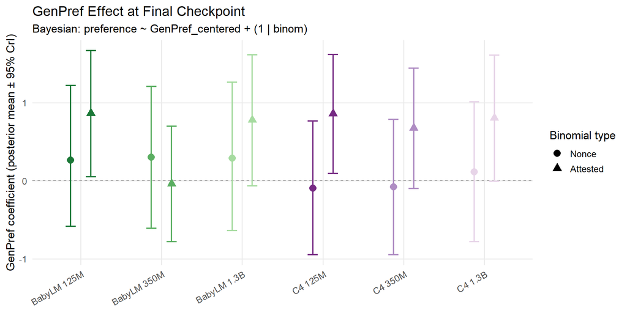

```r
bind_rows(nonce_genpref_final, attested_genpref_final) %>%
  mutate(
    model     = fct_model(model),
    item_type = factor(item_type, levels = c("Nonce", "Attested"))
  ) %>%
  ggplot(aes(x = model, y = estimate, color = model, shape = item_type)) +
  geom_hline(yintercept = 0, linetype = "dashed", color = "gray60") +
  geom_errorbar(aes(ymin = lower, ymax = upper), width = 0.25,
                position = position_dodge(0.5), linewidth = 0.8) +
  geom_point(size = 3.5, position = position_dodge(0.5)) +
  scale_color_manual(values = CORPUS_COLORS, guide = "none") +
  scale_shape_manual(values = c("Nonce" = 16, "Attested" = 17)) +
  labs(
    x        = NULL,
    y        = "GenPref coefficient (posterior mean ± 95% CrI)",
    title    = "GenPref Effect at Final Checkpoint",
    subtitle = "Bayesian: preference ~ GenPref_centered + (1 | binom)",
    shape    = "Binomial type"
  ) +
  theme_minimal(base_size = 13) +
  theme(
    axis.text.x      = element_text(angle = 30, hjust = 1),
    panel.grid.minor = element_blank(),
    legend.position  = "right"
  )
```

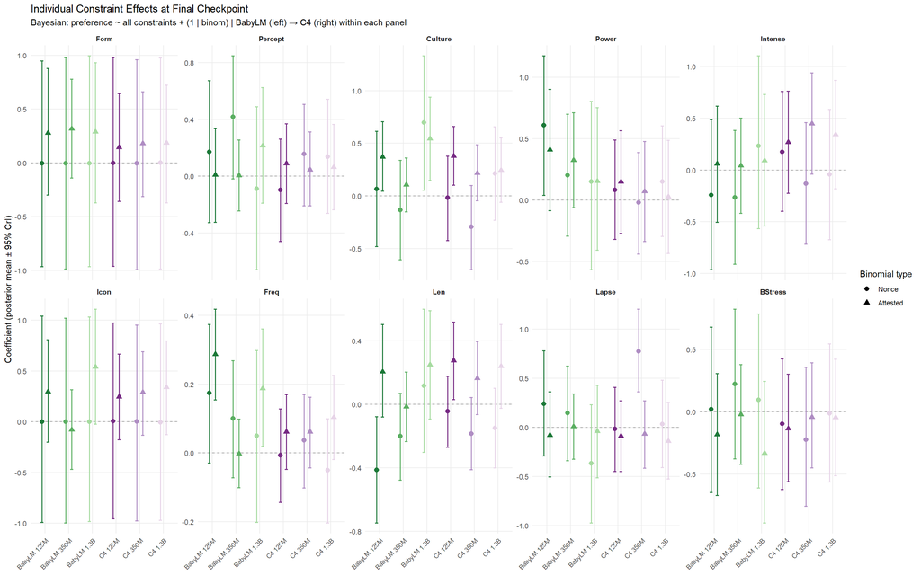

```r
bind_rows(nonce_constraint_final, attested_constraint_final) %>%
  mutate(
    model      = fct_model(model),
    item_type  = factor(item_type, levels = c("Nonce", "Attested")),
    constraint = factor(constraint, levels = CONSTRAINT_COLS)
  ) %>%
  ggplot(aes(x = model, y = estimate, color = model, shape = item_type)) +
  geom_hline(yintercept = 0, linetype = "dashed", color = "gray60") +
  geom_errorbar(aes(ymin = lower, ymax = upper), width = 0.25,
                position = position_dodge(0.5), linewidth = 0.7) +
  geom_point(size = 2.5, position = position_dodge(0.5)) +
  facet_wrap(~ constraint, scales = "free_y", ncol = 5) +
  scale_color_manual(values = CORPUS_COLORS, guide = "none") +
  scale_shape_manual(values = c("Nonce" = 16, "Attested" = 17)) +
  labs(
    x        = NULL,
    y        = "Coefficient (posterior mean ± 95% CrI)",
    title    = "Individual Constraint Effects at Final Checkpoint",
    subtitle = "Bayesian: preference ~ all constraints + (1 | binom) | BabyLM (left) → C4 (right) within each panel",
    shape    = "Binomial type"
  ) +
  theme_minimal(base_size = 11) +
  theme(
    axis.text.x      = element_text(angle = 45, hjust = 1, size = 8),
    strip.text       = element_text(face = "bold"),
    panel.grid.minor = element_blank(),
    legend.position  = "right"
  )
```

### Part B: Effects Over Training

Fit Bayesian models at logarithmically-sampled checkpoints using a **fit → extract → discard** strategy: model objects are never accumulated in memory. Extracted coefficients are saved to CSV after each item-type loop so the notebook is resumable if interrupted (brms will skip refitting from cache, and the CSVs will already hold any completed extractions).

```r
cat(sprintf(
  "Training data: nonce %d rows (%d checkpoints), attested %d rows (%d checkpoints)\n",
  nrow(training_nonce),    n_distinct(training_nonce$checkpoint),
  nrow(training_attested), n_distinct(training_attested$checkpoint)
))
```

```
## Training data: nonce 14934 rows (87 checkpoints), attested 67716 rows (87 checkpoints)
```

```r
# Paths for cached trajectory CSVs
traj_cache <- list(
  nonce_genpref    = file.path(processed_path, "traj_nonce_genpref_bayes.csv"),
  attested_genpref = file.path(processed_path, "traj_attested_genpref_bayes.csv"),
  attested_freq    = file.path(processed_path, "traj_attested_freq_bayes.csv")
)
```

#### Nonce Binomials: Training Trajectory

```r
# ── Load from cache if available, otherwise fit ──────────────────────────────
if (file.exists(traj_cache$nonce_genpref)) {
  message("Loading nonce GenPref trajectory from cache: ", traj_cache$nonce_genpref)
  nonce_genpref_traj <- read_csv(traj_cache$nonce_genpref, show_col_types = FALSE)
} else {
  nonce_traj_rows <- list()

  for (model_name in unique(training_nonce$model)) {
    model_df <- training_nonce %>% filter(model == model_name)

    for (ckpt in unique(model_df$checkpoint)) {
      cat(sprintf("\n=== %s | checkpoint %s (NONCE) ===\n", model_name, ckpt))
      ckpt_data <- model_df %>% filter(checkpoint == ckpt)

      fit_a <- brm(
        preference ~ GenPref_centered + (1 | binom),
        data    = ckpt_data, family = gaussian(), prior = bayes_priors,
        chains  = 4, cores = 4, iter = 12000, warmup = 6000, seed = 964,
        silent  = 2,
        file    = sprintf("brms_cache/training_nonce_%s_%s_modelA",
                          gsub("[/:-]", "_", model_name), ckpt),
        control = list(adapt_delta = 0.98)
      )
      print(round(summary(fit_a)$fixed, 3))
      rstan::check_hmc_diagnostics(fit_a$fit)

      # Extract immediately, discard model
      coefs <- fixef(fit_a)
      nonce_traj_rows[[length(nonce_traj_rows) + 1]] <- tibble(
        model      = model_name,
        checkpoint = ckpt,
        tokens     = unique(ckpt_data$tokens),
        step       = unique(ckpt_data$step),
        item_type  = "Nonce",
        estimate   = coefs["GenPref_centered", "Estimate"],
        lower      = coefs["GenPref_centered", "Q2.5"],
        upper      = coefs["GenPref_centered", "Q97.5"]
      )

      rm(fit_a); gc()
    }
  }

  nonce_genpref_traj <- bind_rows(nonce_traj_rows)
  write_csv(nonce_genpref_traj, traj_cache$nonce_genpref)
  message("Saved nonce GenPref trajectory to: ", traj_cache$nonce_genpref)
}
```

#### Attested Binomials: Training Trajectory

```r
# ── Frequency parameters to track ───────────────────────────────────────────
FREQ_PARAMS <- c(
  "OverallFreq_scaled",
  "RelFreq_centered",
  "GenPref_centered:OverallFreq_scaled",
  "RelFreq_centered:OverallFreq_scaled"
)

if (file.exists(traj_cache$attested_genpref) && file.exists(traj_cache$attested_freq)) {
  message("Loading attested trajectories from cache.")
  attested_genpref_traj <- read_csv(traj_cache$attested_genpref, show_col_types = FALSE)
  attested_freq_traj    <- read_csv(traj_cache$attested_freq,    show_col_types = FALSE)
} else {
  attested_genpref_rows <- list()
  attested_freq_rows    <- list()

  for (model_name in unique(training_attested$model)) {
    model_df <- training_attested %>% filter(model == model_name)

    for (ckpt in unique(model_df$checkpoint)) {
      cat(sprintf("\n=== %s | checkpoint %s (ATTESTED) ===\n", model_name, ckpt))
      ckpt_data <- model_df %>% filter(checkpoint == ckpt)

      fit_a <- brm(
        preference ~ GenPref_centered * OverallFreq_scaled +
                     RelFreq_centered * OverallFreq_scaled + (1 | binom),
        data    = ckpt_data, family = gaussian(), prior = bayes_priors,
        chains  = 4, cores = 4, iter = 12000, warmup = 6000, seed = 964,
        silent  = 2,
        file    = sprintf("brms_cache/training_attested_%s_%s_modelA",
                          gsub("[/:-]", "_", model_name), ckpt),
        control = list(adapt_delta = 0.98)
      )
      print(round(summary(fit_a)$fixed, 3))
      rstan::check_hmc_diagnostics(fit_a$fit)

      coefs  <- fixef(fit_a)
      tokens <- unique(ckpt_data$tokens)
      step   <- unique(ckpt_data$step)

      # GenPref trajectory row
      attested_genpref_rows[[length(attested_genpref_rows) + 1]] <- tibble(
        model      = model_name,
        checkpoint = ckpt,
        tokens     = tokens,
        step       = step,
        item_type  = "Attested",
        estimate   = coefs["GenPref_centered", "Estimate"],
        lower      = coefs["GenPref_centered", "Q2.5"],
        upper      = coefs["GenPref_centered", "Q97.5"]
      )

      # Frequency trajectory rows (one row per parameter)
      for (param in FREQ_PARAMS) {
        if (param %in% rownames(coefs)) {
          attested_freq_rows[[length(attested_freq_rows) + 1]] <- tibble(
            model      = model_name,
            checkpoint = ckpt,
            tokens     = tokens,
            step       = step,
            parameter  = param,
            estimate   = coefs[param, "Estimate"],
            lower      = coefs[param, "Q2.5"],
            upper      = coefs[param, "Q97.5"]
          )
        }
      }

      rm(fit_a); gc()
    }
  }

  attested_genpref_traj <- bind_rows(attested_genpref_rows)
  attested_freq_traj    <- bind_rows(attested_freq_rows)

  write_csv(attested_genpref_traj, traj_cache$attested_genpref)
  write_csv(attested_freq_traj,    traj_cache$attested_freq)
  message("Saved attested trajectories to cache.")
}
```

#### Training Trajectory: Plots

[figure not shown]

```r
bind_rows(nonce_genpref_traj, attested_genpref_traj) %>%
  mutate(model = fct_model(model)) %>%
  ggplot(aes(x = tokens, y = estimate, color = model, fill = model)) +
  geom_ribbon(aes(ymin = lower, ymax = upper), alpha = 0.2, color = NA) +
  geom_line(linewidth = 1) +
  geom_hline(yintercept = 0, linetype = "dashed", color = "gray60") +
  facet_grid(item_type ~ model, scales = "free_x") +
  scale_x_continuous(labels = scales::label_number(scale = 1e-9, suffix = "B")) +
  scale_color_manual(values = CORPUS_COLORS) +
  scale_fill_manual(values  = CORPUS_COLORS) +
  labs(
    x        = "Training tokens",
    y        = "GenPref coefficient (posterior mean ± 95% CrI)",
    title    = "Bayesian GenPref Effect Over Training",
    subtitle = "Nonce (top) vs. Attested (bottom) | BabyLM (left) → C4 (right)"
  ) +
  theme_minimal(base_size = 13) +
  theme(
    strip.text       = element_text(face = "bold"),
    legend.position  = "none",
    panel.grid.minor = element_blank()
  )
```

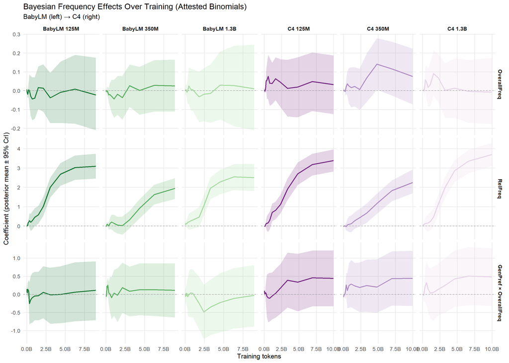

```r
attested_freq_traj %>%
  mutate(
    model     = fct_model(model),
    parameter = factor(
      parameter,
      levels = FREQ_PARAMS,
      labels = c("OverallFreq", "RelFreq",
                 "GenPref × OverallFreq", "RelFreq × OverallFreq")
    )
  ) %>%
  ggplot(aes(x = tokens, y = estimate, color = model, fill = model)) +
  geom_ribbon(aes(ymin = lower, ymax = upper), alpha = 0.2, color = NA) +
  geom_line(linewidth = 1) +
  geom_hline(yintercept = 0, linetype = "dashed", color = "gray60") +
  facet_grid(parameter ~ model, scales = "free") +
  scale_x_continuous(labels = scales::label_number(scale = 1e-9, suffix = "B")) +
  scale_color_manual(values = CORPUS_COLORS) +
  scale_fill_manual(values  = CORPUS_COLORS) +
  labs(
    x        = "Training tokens",
    y        = "Coefficient (posterior mean ± 95% CrI)",
    title    = "Bayesian Frequency Effects Over Training (Attested Binomials)",
    subtitle = "BabyLM (left) → C4 (right)"
  ) +
  theme_minimal(base_size = 13) +
  theme(
    strip.text       = element_text(face = "bold"),
    legend.position  = "none",
    panel.grid.minor = element_blank()
  )
```

#### Training Trajectory: Individual Constraint Effects (OLS)

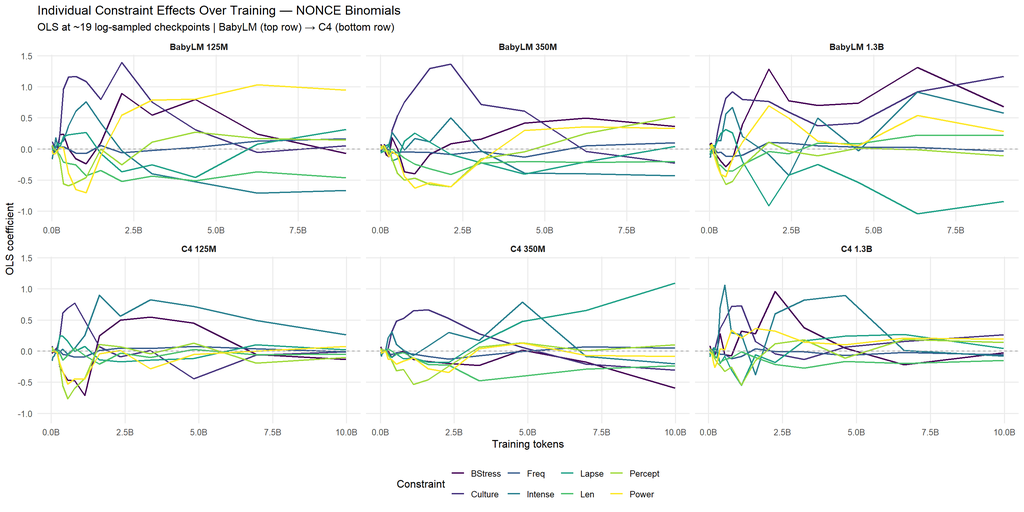

```r
nonce_constraints %>%
  mutate(model = fct_model(model)) %>%
  ggplot(aes(x = tokens, y = coefficient, color = constraint)) +
  geom_line(linewidth = 0.8) +
  geom_hline(yintercept = 0, linetype = "dashed", color = "gray60") +
  facet_wrap(~ model, scales = "free_x", ncol = 3) +
  scale_x_continuous(labels = scales::label_number(scale = 1e-9, suffix = "B")) +
  scale_color_viridis_d() +
  labs(
    x        = "Training tokens",
    y        = "OLS coefficient",
    title    = "Individual Constraint Effects Over Training — NONCE Binomials",
    subtitle = "OLS at ~19 log-sampled checkpoints | BabyLM (top row) → C4 (bottom row)",
    color    = "Constraint"
  ) +
  theme_minimal(base_size = 12) +
  theme(
    strip.text       = element_text(face = "bold"),
    panel.grid.minor = element_blank(),
    legend.position  = "bottom"
  ) +
  guides(color = guide_legend(nrow = 2))
```

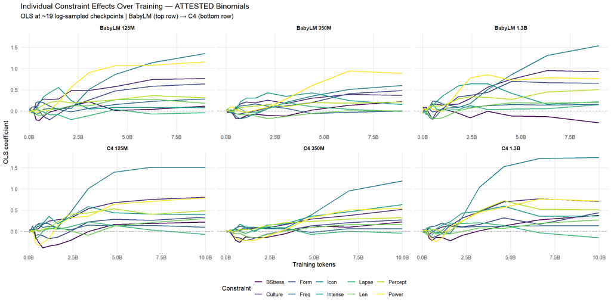

```r
attested_constraints %>%
  mutate(model = fct_model(model)) %>%
  ggplot(aes(x = tokens, y = coefficient, color = constraint)) +
  geom_line(linewidth = 0.8) +
  geom_hline(yintercept = 0, linetype = "dashed", color = "gray60") +
  facet_wrap(~ model, scales = "free_x", ncol = 3) +
  scale_x_continuous(labels = scales::label_number(scale = 1e-9, suffix = "B")) +
  scale_color_viridis_d() +
  labs(
    x        = "Training tokens",
    y        = "OLS coefficient",
    title    = "Individual Constraint Effects Over Training — ATTESTED Binomials",
    subtitle = "OLS at ~19 log-sampled checkpoints | BabyLM (top row) → C4 (bottom row)",
    color    = "Constraint"
  ) +
  theme_minimal(base_size = 12) +
  theme(
    strip.text       = element_text(face = "bold"),
    panel.grid.minor = element_blank(),
    legend.position  = "bottom"
  ) +
  guides(color = guide_legend(nrow = 2))
```

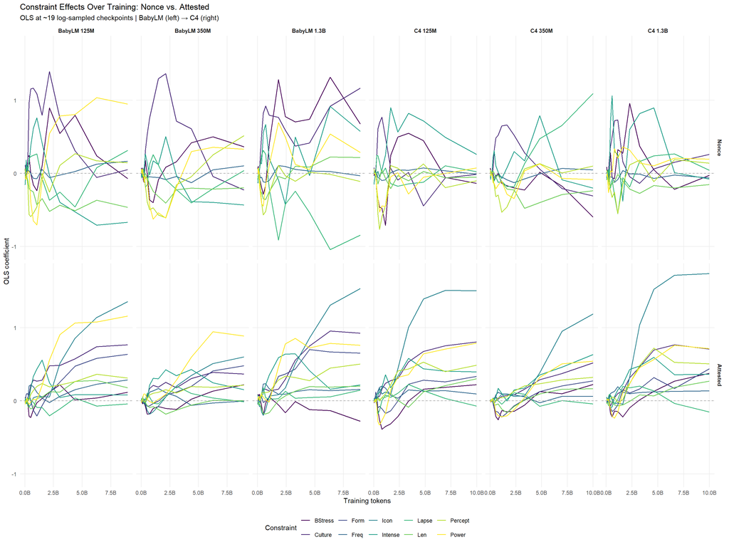

```r
bind_rows(
  nonce_constraints    %>% mutate(item_type = "Nonce"),
  attested_constraints %>% mutate(item_type = "Attested")
) %>%
  mutate(
    model     = fct_model(model),
    item_type = factor(item_type, levels = c("Nonce", "Attested"))
  ) %>%
  ggplot(aes(x = tokens, y = coefficient, color = constraint)) +
  geom_line(linewidth = 0.7) +
  geom_hline(yintercept = 0, linetype = "dashed", color = "gray60") +
  facet_grid(item_type ~ model, scales = "free_x") +
  scale_x_continuous(labels = scales::label_number(scale = 1e-9, suffix = "B")) +
  scale_color_viridis_d() +
  labs(
    x        = "Training tokens",
    y        = "OLS coefficient",
    title    = "Constraint Effects Over Training: Nonce vs. Attested",
    subtitle = "OLS at ~19 log-sampled checkpoints | BabyLM (left) → C4 (right)",
    color    = "Constraint"
  ) +
  theme_minimal(base_size = 11) +
  theme(
    strip.text       = element_text(face = "bold"),
    panel.grid.minor = element_blank(),
    legend.position  = "bottom"
  ) +
  guides(color = guide_legend(nrow = 2))
```